# RM-ANOVA for coevolution with a seed bank

Load organized data

### Adjusting variable types for lme

In the lme models used below the fixed effects need to be specified as factors. In this experiment these are: *Phage, seed.bank and time*. However for the auto correlation specification time needs to be specified as an integer. To fulfill both requirements we use the experimental day rather than transfer as the time unit, since samples taken once a day but twice per transfer. This will be simply *time x 2*. From that we make a separate variable which will be the factor of the time.

```r
d <-
  d%>%
  #make time an integer for correlation structure
  # by converting to days as time unit
  mutate(Time=as.integer(2*Time))%>%
  # for the lme model all fixed effects need to be factors
  mutate(time.fct=as.factor(Time))%>%
  mutate(phage=as.factor(phage))%>%
  mutate(seed.bank=as.factor(seed.bank))%>%
  #ajust factor order for seed bank
  mutate(seed.bank = fct_relevel(seed.bank, "long","short","none"))
```

Select response variable to be analyzed

```r
var.response <- "spore/ml"

d <- d %>%
  mutate(response=spore.ml )%>%
  #remove non-sporulating host sample
  filter(host=="WT")
```

Here we analyze **spore/ml** .

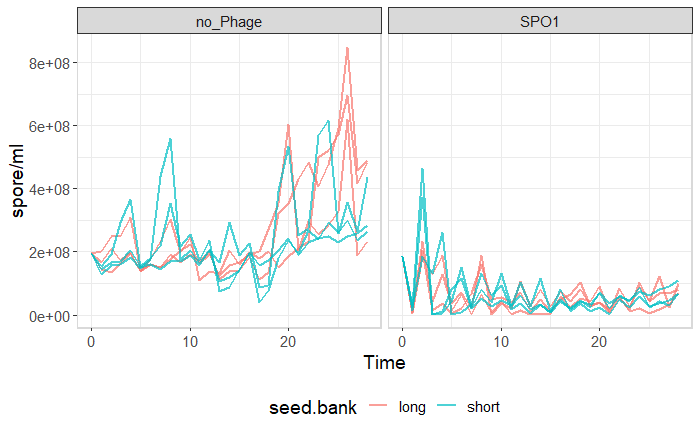

```r
d%>%
ggplot(aes(x=Time, y=response))+
      geom_line(aes(group=flask,color=seed.bank), size=1, alpha=0.7)+
        facet_wrap(~phage)+
      theme_bw()+
      panel_border()+
      theme(legend.position = "bottom",
            text=element_text(size=14))+
      ylab(var.response)
```

### Test data for homogeneity of variances

This is an assumption of ANOVA tests.

Based on : https://www.datanovia.com/en/lessons/homogeneity-of-variance-test-in-r/ Using “Levene’s test” that according to website is the most commonly used test for this purpose. This test has a null hypothesis of equal variance. So getting P>0.05 suggests homogenic variance.

```r
# Levene's test with multiple independent variables
car::leveneTest(response ~ phage*seed.bank*line, data = d)
```

```
Levene's Test for Homogeneity of Variance (center = median)
       Df F value    Pr(>F)
group  11  3.3453 0.0002143 ***
      336
---
Signif. codes:  0 ‘***’ 0.001 ‘**’ 0.01 ‘*’ 0.05 ‘.’ 0.1 ‘ ’ 1
```

The data does not fulfill the assumption of equal variance across test groups.

## Log transform the data

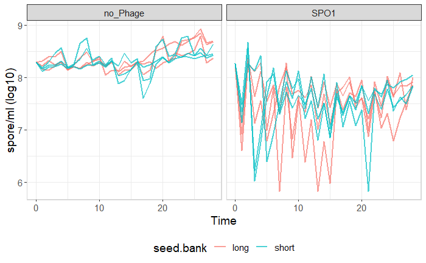

```r
d <- d%>%
  mutate(log.response=log10(response))


d%>%
ggplot(aes(x=Time, y=log.response))+
      geom_line(aes(group=flask,color=seed.bank), size=1, alpha=0.7)+
        facet_wrap(~phage)+
      theme_bw()+
      panel_border()+
      theme(legend.position = "bottom",
            text=element_text(size=14))+
      ylab(paste(var.response,"(log10)"))
```

### Test transformed data for homogeneity of variances

```r
# Levene's test with multiple independent variables
car::leveneTest(log.response ~ phage*seed.bank*line, data = d)
```

```
Levene's Test for Homogeneity of Variance (center = median)
       Df F value    Pr(>F)
group  11  7.6561 8.207e-12 ***
      336
---
Signif. codes:  0 ‘***’ 0.001 ‘**’ 0.01 ‘*’ 0.05 ‘.’ 0.1 ‘ ’ 1
```

The data does not fulfill the assumption of equal variance across test groups.

# Box-Cox transformation

`powerTransform` uses the maximum likelihood-like approach of Box and Cox (1964) to select a transformation of a univariate or multivariate response for normality, linearity and/or constant variance. (help page for `car::powerTransform`)

```r
# Multivariate transformation to normality within levels of 'htype'
bx.cx <- powerTransform(response ~ phage*seed.bank*line, d)
summary(bx.cx)
```

```
bcPower Transformation to Normality
   Est Power Rounded Pwr Wald Lwr Bnd Wald Upr Bnd
Y1     0.341        0.33       0.2789       0.4032

Likelihood ratio test that transformation parameter is equal to 0
 (log transformation)
```

|  | LRT | df | pval |
| --- | --- | --- | --- |
| LR test, lambda = (0) | 131.5813 | 1 | < 2.22e-16 |

```
Likelihood ratio test that no transformation is needed
```

|  | LRT | df | pval |
| --- | --- | --- | --- |
| LR test, lambda = (1) | 305.5043 | 1 | < 2.22e-16 |

Plot the profile log-likelihood for Box-Cox transformations .

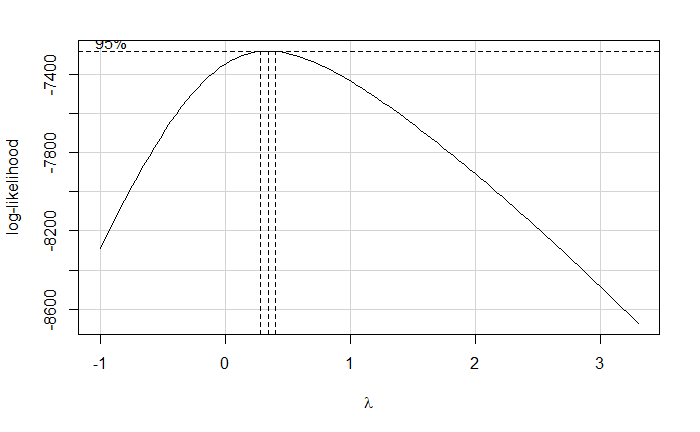

```r
  with(d, boxCox(response ~ phage*seed.bank*line,
                 lambda = seq(-1, bx.cx$roundlam+3, by = 0.1),
                 family="bcPower"))
```

Transform using Box-Cox $\lambda$ (rounded).

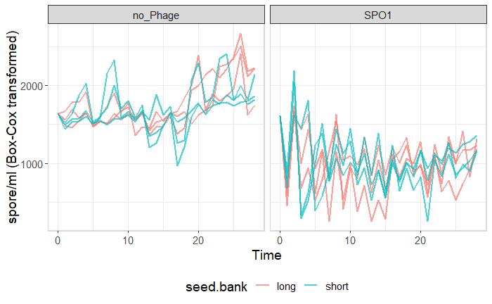

```r
d <- d%>%
  mutate(bxcx.response=bcPower(response, bx.cx$roundlam))

d%>%
ggplot(aes(x=Time, y=bxcx.response))+
      geom_line(aes(group=flask,color=seed.bank), size=1, alpha=0.7)+
        facet_wrap(~phage)+
      theme_bw()+
      panel_border()+
      theme(legend.position = "bottom",
            text=element_text(size=14))+
      ylab(paste(var.response,"(Box-Cox transformed)"))
```

### Test transformed data for homogeneity of variances

```r
# Levene's test with multiple independent variables
car::leveneTest(bxcx.response ~ phage*seed.bank*line, data = d)
```

```
Levene's Test for Homogeneity of Variance (center = median)
       Df F value Pr(>F)
group  11  2.1328 0.0178 *
      336
---
Signif. codes:  0 ‘***’ 0.001 ‘**’ 0.01 ‘*’ 0.05 ‘.’ 0.1 ‘ ’ 1
```

# RM-ANOVA model selection

To account for time series auto-correlation we will specify correlation structure to the lme model. We will test various corARMA correlation structures and choose by lowest AIC. This is a combined auto-regressive model, AR(p), and moving average model, MA(q). I here take a model selection approach to choose these parameters (lowest AIC). Since we have a seasonality of lag 2 due to transfer we will look at lag up to 2 for both AR and MA. Note that a corARMA(p=1, q=0) is the same as corAR1.

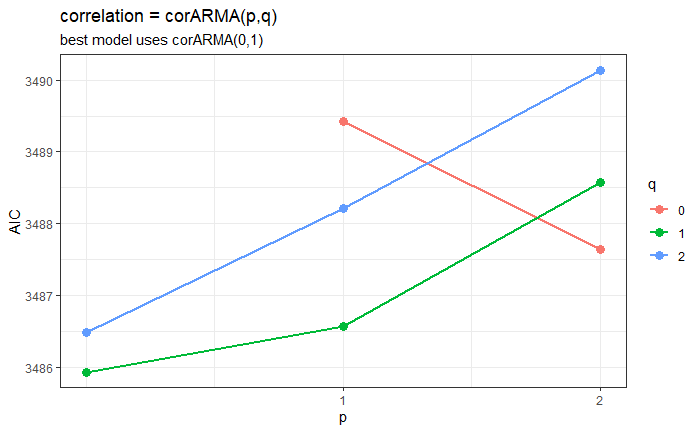

```r
# initalise empty list to save models
l.rm <- list()

# initalise empty table to collect model data
pq.aic <- tibble()



for(Q in c(0:2)){
  for (P in c(0:2)){

    #skip corARMA(0,0)
    if (P==0 & Q==0) next

    #run model
    cur.model <- d%>%
      lme(bxcx.response ~ phage * seed.bank * time.fct ,
          random = ~1|flask,
          correlation = corARMA(form = ~ Time | flask, p=P,q=Q),
            data = .)
    l.rm[[paste0("ARMA_P",P,"Q",Q)]] <- cur.model

    cur.tbl <- broom.mixed::glance(cur.model)%>%
      mutate(p=P)%>%
      mutate(q=Q)


      pq.aic <- bind_rows(pq.aic,cur.tbl)

  }
}

# get list order by AIC
pq.aic <-
  pq.aic%>%arrange(AIC)%>%
  # model name
  mutate(arma=paste0("ARMA_P",p,"Q",q))

# save the best model
m.best <- l.rm[[pq.aic$arma[1]]]
best <- paste0("corARMA(",pq.aic$p[1],",",pq.aic$q[1],")")

pq.aic%>%
  mutate(q=as.character(q))%>%
  ggplot(aes(p,AIC))+
  geom_line(aes(color=q),size=1)+
  geom_point(aes(color=q),size=3)+
  theme_bw()+
  scale_x_continuous(breaks = 1:10)+
  ggtitle("correlation = corARMA(p,q)",paste("best model uses", best))
```

```r
# compare best 5 models by AIC order
t.models <- anova(l.rm[[pq.aic$arma[5]]],
                  l.rm[[pq.aic$arma[4]]],
                  l.rm[[pq.aic$arma[3]]],
                  l.rm[[pq.aic$arma[2]]],
                  l.rm[[pq.aic$arma[1]]])

t.models%>%
  tibble()%>%
  select(-call)%>%
  mutate(arma=pq.aic$arma[1:5])
```

| Model | df | AIC | BIC | logLik | Test | L.Ratio | p-value | arma |
| --- | --- | --- | --- | --- | --- | --- | --- | --- |
| 1 | 121 | 3488.207 | 3905.263 | -1623.104 |  | NA | NA | ARMA_P0Q1 |
| 2 | 120 | 3487.641 | 3901.250 | -1623.821 | 1 vs 2 | 1.434093 | 0.2310976 | ARMA_P0Q2 |
| 3 | 120 | 3486.571 | 3900.179 | -1623.285 |  | NA | NA | ARMA_P1Q1 |
| 4 | 120 | 3486.489 | 3900.098 | -1623.245 |  | NA | NA | ARMA_P2Q0 |
| 5 | 119 | 3485.928 | 3896.090 | -1623.964 | 4 vs 5 | 1.439078 | 0.2302887 | ARMA_P1Q2 |

```r
NA
```

# best model is corARMA(0,1)

Though it is not significantly better than the the other models.

**Results of selected model**

```r
# best model data
pq.aic%>%
  slice_min(AIC)
```

| sigma | logLik | AIC | BIC | p | q | arma |
| --- | --- | --- | --- | --- | --- | --- |
| 219.9905 | -1623.964 | 3485.928 | 3896.09 | 0 | 1 | ARMA_P0Q1 |

```r
#display best model results
  anova(l.rm[[pq.aic$arma[1]]])
```

|  | numDF | denDF | F-value | p-value |
| --- | --- | --- | --- | --- |
| (Intercept) | 1 | 224 | 7951.464 | <.0001 |
| phage | 1 | 8 | 518.072 | <.0001 |
| seed.bank | 1 | 8 | 0.615 | 0.4554 |
| time.fct | 28 | 224 | 20.352 | <.0001 |
| phage:seed.bank | 1 | 8 | 2.157 | 0.1802 |
| phage:time.fct | 28 | 224 | 10.362 | <.0001 |
| seed.bank:time.fct | 28 | 224 | 0.965 | 0.5207 |
| phage:seed.bank:time.fct | 28 | 224 | 0.886 | 0.6347 |

```r
NA
```

Seed-bank treatment has no significant effect on spore population densities, neither as main effect or in interaction with other predictors. phage and time both significantly effect spore densities. Before looking into the potential drivers of this effect we evaluate the model.

### How sensitive would the result be to model selected?

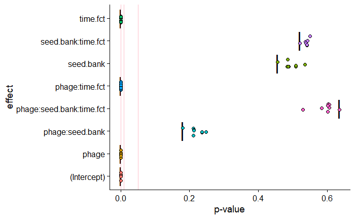

```r
# put all model results in tibble
all.models <-
  map(l.rm, anova.lme) %>%
  map(rownames_to_column)%>%
  bind_rows(.id = "arma")%>%
  rename(effect=rowname)

arma.best <- paste0("ARMA_P",pq.aic$p[1],"Q",pq.aic$q[1])
selected <-
  all.models%>%
  filter(arma==arma.best)


all.models%>%
  mutate(effect=fct_inorder(effect))%>%
  ggplot(aes(x=effect, y=`p-value`))+
   geom_point(data = selected, color="black", size=10, shape="|")+
  geom_hline(yintercept = c(0.05,0.01,1e-3), color="pink")+
  geom_jitter(aes(fill=effect),width = 0.2, height = 0,
              shape=21, size=2, show.legend = F)+
  coord_flip()+
  theme_cowplot()
```

The line marks the p-values of the selected model, and the points shoe p-values of all models tested (including best). The results are pretty similar across the models.

#### Distribution of model residuals

For the best model.

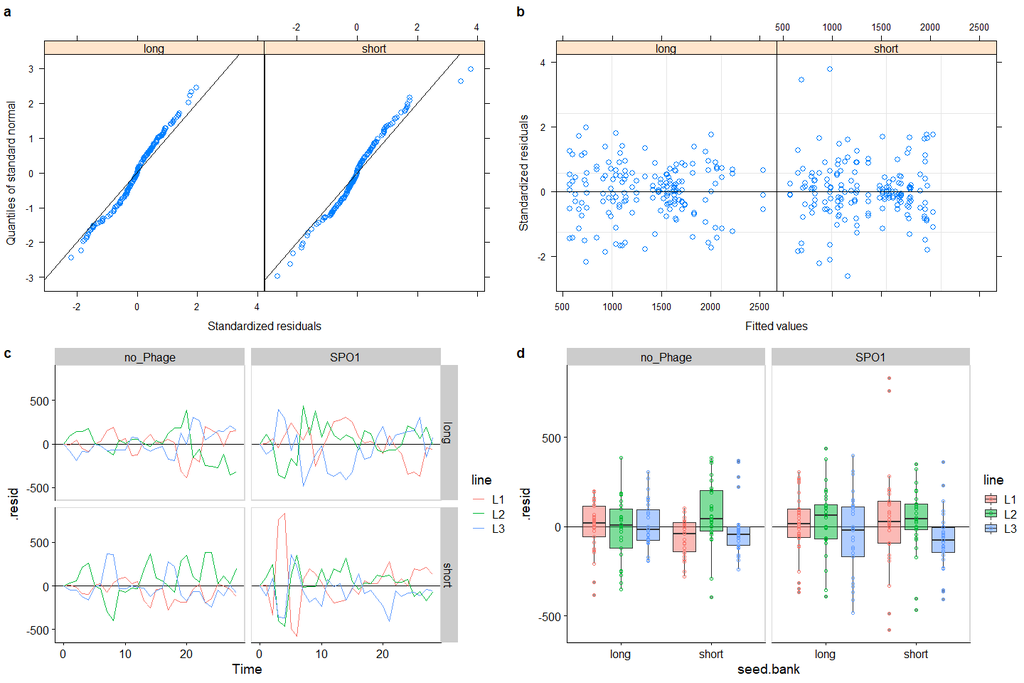

```r
p1 <-
  #qqplot by seed bank
  qqnorm(m.best,~ resid(., type = "p")|seed.bank, abline = c(0, 1))

p2 <-
  # standardized residuals versus fitted values by seed.bank
plot(m.best, resid(., type = "p") ~ fitted(.) | seed.bank, abline = 0)

p3 <-
broom.mixed::augment(m.best)%>%
  ggplot(aes(Time,.resid)) +
  geom_hline(yintercept = 0)+
  geom_line(aes(color=line))+
  facet_grid(seed.bank~phage)+
  theme_cowplot()+panel_border()

p4 <-
broom.mixed::augment(m.best)%>%
  ggplot(aes(seed.bank,.resid)) +
  geom_hline(yintercept = 0)+
  geom_boxplot(aes(fill=line),alpha=.5, position = position_dodge(width = .9))+
  geom_point(aes(color=line), position = position_dodge(width = .9), shape=21)+
  facet_wrap(~phage)+
  theme_cowplot()+panel_border()



plot_grid(p1,p2,p3,p4, nrow = 2, labels = 'auto')
```

# post hoc

### Visualize EMM of interactions

```
STATS is longer than the extent of 'dim(x)[MARGIN]'NOTE: Results may be misleading due to involvement in interactions
```

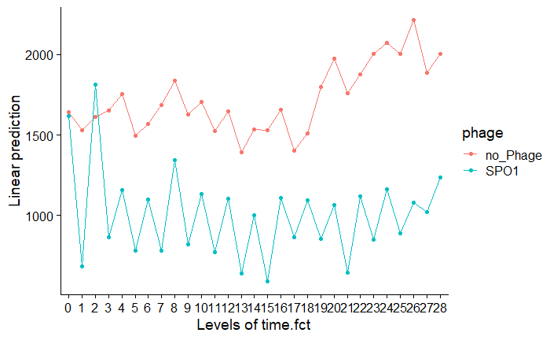

```r
# plot
emmip(m.best, phage~time.fct)+
  theme_cowplot()
```

Spores are consistently lower in presence of phage. a rise in spore density is seen in the second half of the experiment in the absence of phage. This complements the observation of decline on vegetative cells in non-infected WT culture in the same period.

What is the source of the phageXtime interaction being significant? Breaking up the model estimated by these two predictors next.

```r
coevo.emm <- emmeans(m.best, ~  phage * time.fct)
```

```
STATS is longer than the extent of 'dim(x)[MARGIN]'NOTE: Results may be misleading due to involvement in interactions
```

```r
coevo.pairs <- pairs(coevo.emm, simple="phage")%>%
  tidy

p1 <-
  coevo.pairs%>%
  # make time continuous for plotting.
  mutate(day=as.numeric(time.fct))%>%
  #plot
  ggplot(aes(x=day, y=estimate))+
    #add 0 line
  geom_hline(yintercept = 0, color="red")+
  geom_point()+
  geom_line()+
  facet_grid(contrast~.)+
  theme_cowplot()+
  panel_border()

p2 <- coevo.pairs%>%
  # focus on phage infected
  # filter(phage=="SPO1")%>%
  # # make time continuous for plotting.
  mutate(day=as.numeric(time.fct))%>%
  # arrange panel order
  mutate(contrast=fct_relevel(contrast, "long - short", after = 0))%>%
  #plot
  ggplot(aes(x=day, y=p.value))+
    #add 0.05 signifcance thrshold
  geom_hline(yintercept = 0.05, color="red")+
  geom_point()+
  geom_line()+
  facet_grid(contrast~.)+
  theme_cowplot()+
  panel_border()
```

[output not shown]

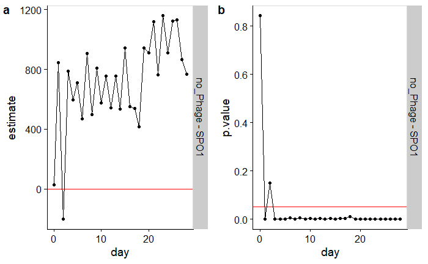

```r
plot_grid(p1,p2, labels = "auto")
```

The phage effect on spore density is consistent across time except for a brief period in the first few samples.

The major differences seem to be in phage-treated cultures, between first two transfers and the rest of the data.

# Summary

Spore densities were significantly lower in phage infected cultures, in agreement with the previous observations of lower vegetative cells and overall cell density. We find no difference in spore densities between the two seed-bank treatments in both long and short seed bank treatments. In the non-infected lines we find a trend on increase in spore densities, mostly in second half of the experiment.